# Interactions - Assignment

Simon Munzert

21.09.2017

### Assignment

#### 1. Replicate the results from the motivating setup Braumoeller (2004, IO 58) uses to make his point and that leads to Table 1. Use the parameters from footnote 1!

```r
# model 1
set.seed(123)
N <- 1000
x1 <- runif(N, 0, 1)
x2 <- runif(N, 0, 1)
e <- rnorm(N, 0, 1)
y <- 0.2 + x1 + 2*x2 + 3*x1*x2 + e
summary(model1 <- lm(y ~ x1 + x2 + x1*x2))
```

```
##
## Call:
## lm(formula = y ~ x1 + x2 + x1 * x2)
##
## Residuals:
##     Min      1Q  Median      3Q     Max
## -3.0668 -0.6957  0.0217  0.7201  3.3336
##
## Coefficients:
##             Estimate Std. Error t value Pr(>|t|)
## (Intercept)   0.1875     0.1344   1.395    0.163
## x1            1.1205     0.2259   4.961 8.25e-07 ***
## x2            2.0658     0.2283   9.050  < 2e-16 ***
## x1:x2         2.8446     0.3888   7.315 5.27e-13 ***
## ---
## Signif. codes:  0 '***' 0.001 '**' 0.01 '*' 0.05 '.' 0.1 ' ' 1
##
## Residual standard error: 1.011 on 996 degrees of freedom
## Multiple R-squared:  0.5985, Adjusted R-squared:  0.5973
## F-statistic:   495 on 3 and 996 DF,  p-value: < 2.2e-16
```

```r
# model 2: recoding x2
x2_star <- x2 + 0.4
y <- 0.2 + x1 + 2*x2_star + 3*x1*x2_star + e
summary(model2 <- lm(y ~ x1 + x2_star + x1*x2_star))
```

```
##
## Call:
## lm(formula = y ~ x1 + x2_star + x1 * x2_star)
##
## Residuals:
##     Min      1Q  Median      3Q     Max
## -3.0668 -0.6957  0.0217  0.7201  3.3336
##
## Coefficients:
##             Estimate Std. Error t value Pr(>|t|)
## (Intercept)   0.1611     0.2190   0.736   0.4621
## x1            1.1827     0.3692   3.203   0.0014 **
## x2_star       2.0658     0.2283   9.050  < 2e-16 ***
## x1:x2_star    2.8446     0.3888   7.315 5.27e-13 ***
## ---
## Signif. codes:  0 '***' 0.001 '**' 0.01 '*' 0.05 '.' 0.1 ' ' 1
##
## Residual standard error: 1.011 on 996 degrees of freedom
## Multiple R-squared:  0.6737, Adjusted R-squared:  0.6728
## F-statistic: 685.6 on 3 and 996 DF,  p-value: < 2.2e-16
```

```r
stargazer(model1, model2, header = FALSE, style = "apsr", type = "html", out = "../output/braumoeller_replication.html")
```

[output not shown]

#### 2. Consider the “wage2” data set from the wooldridge package! The outcome of interest is monthly earnings. Make yourself familiar with the data set and, based on the observational data, come up with ad hoc hypotheses that predict wage. Also, try to develop a hypothesis where one variable (continuous) mediates the effect of another. Estimate a model that predicts wage using a set of variables, including the interaction variables. Visualize the interaction effect appropriately and interpret your findings!

```r
data(wage2)
summary(model_out <- lm(wage ~ tenure + educ + exper*IQ, data = wage2)) # IQ probably more important when experience is low?
```

```
##
## Call:
## lm(formula = wage ~ tenure + educ + exper * IQ, data = wage2)
##
## Residuals:
##     Min      1Q  Median      3Q     Max
## -870.10 -242.04  -49.87  184.25 2151.44
##
## Coefficients:
##               Estimate Std. Error t value Pr(>|t|)
## (Intercept) -556.10154  252.43884  -2.203  0.02785 *
## tenure         7.36160    2.47099   2.979  0.00297 **
## educ          57.15615    7.04796   8.110  1.6e-15 ***
## exper         17.04883   19.84374   0.859  0.39048
## IQ             5.11349    2.46096   2.078  0.03800 *
## exper:IQ      -0.02081    0.19678  -0.106  0.91580
## ---
## Signif. codes:  0 '***' 0.001 '**' 0.01 '*' 0.05 '.' 0.1 ' ' 1
##
## Residual standard error: 369.4 on 929 degrees of freedom
## Multiple R-squared:  0.1699, Adjusted R-squared:  0.1655
## F-statistic: 38.03 on 5 and 929 DF,  p-value: < 2.2e-16
```

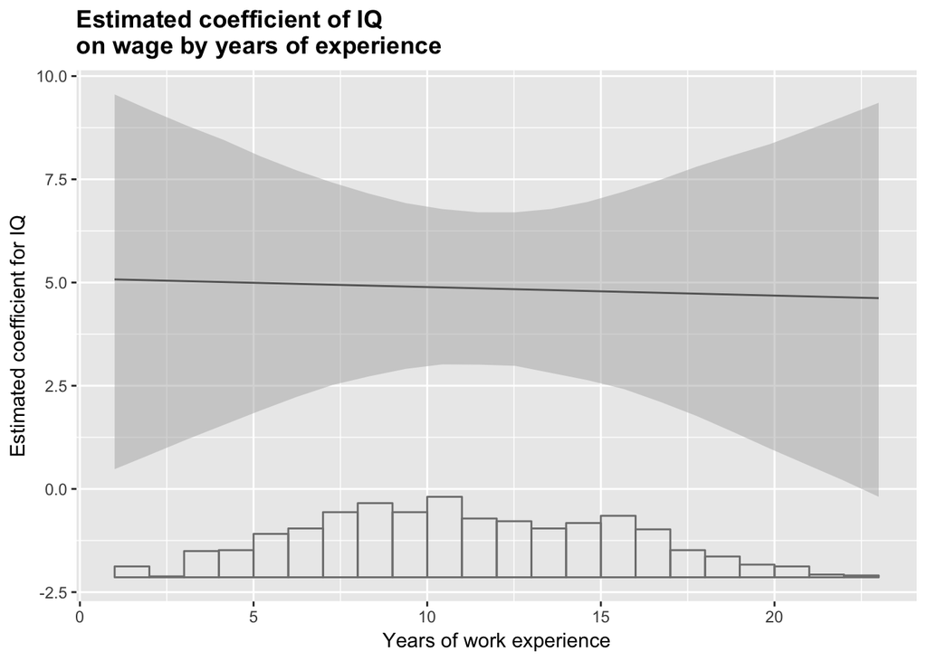

```r
interplot(m = model_out, var1 = "IQ", var2 = "exper", hist  = TRUE) +
  xlab('Years of work experience') +
  ylab('Estimated coefficient for IQ') +
  ggtitle('Estimated coefficient of IQ\non wage by years of experience') +
  theme(plot.title = element_text(face='bold'))
```

#### 3. What determines support for European integration? For the following tasks, please consider the data set “eu-support.dta”, which is a small dataset on individual support for European integration (variable eusupp) in Denmark, Spain and the UK. Your preliminary theorizing suggests that EU support is determined by political ideology and by the country-specific understanding of EU integration.

##### a) Load your data. Next, recode the variable “nation” as follows: 7 = Denmark, 9 = UK, 11 = Spain using the recode() function from the car package. Finally, make the variable a character variable using as.character().

```r
dat <- read_dta("../data/eu-support.dta")
table(dat$nation)
```

```
##
##    7    9   11
## 1001 1351 1006
```

```r
dat$nation <- car::recode(dat$nation, "7 = 'Denmark' ; 9 = 'UK' ; 11 = 'Spain'")
dat$nation <- as.factor(dat$nation)
table(dat$nation)
```

```
##
## Denmark   Spain      UK
##    1001    1006    1351
```

##### b) Build a simple model that predicts EU support with left-right ideology and the country of residence as well as their interactions. Also, control for gender (2 is female), age, and education. Display the results in a regression table!

```r
summary(m1 <- lm(eusupp ~ nation*left_right + sex + age + educ, data = dat))
```

```
##
## Call:
## lm(formula = eusupp ~ nation * left_right + sex + age + educ,
##     data = dat)
##
## Residuals:
##     Min      1Q  Median      3Q     Max
## -4.0190 -0.6295  0.0742  0.7670  2.6752
##
## Coefficients:
##                         Estimate Std. Error t value Pr(>|t|)
## (Intercept)             6.621595   0.148395  44.621  < 2e-16 ***
## nationSpain             1.664620   0.140791  11.823  < 2e-16 ***
## nationUK               -0.178197   0.145029  -1.229    0.219
## left_right              0.134930   0.018717   7.209 7.13e-13 ***
## sex                    -0.175407   0.038218  -4.590 4.63e-06 ***
## age                    -0.001064   0.001198  -0.888    0.375
## educ                   -0.176807   0.007021 -25.184  < 2e-16 ***
## nationSpain:left_right -0.105437   0.025107  -4.199 2.75e-05 ***
## nationUK:left_right    -0.210673   0.025728  -8.189 3.88e-16 ***
## ---
## Signif. codes:  0 '***' 0.001 '**' 0.01 '*' 0.05 '.' 0.1 ' ' 1
##
## Residual standard error: 1.04 on 2965 degrees of freedom
##   (384 observations deleted due to missingness)
## Multiple R-squared:  0.5274, Adjusted R-squared:  0.5261
## F-statistic: 413.6 on 8 and 2965 DF,  p-value: < 2.2e-16
```

##### c) Try to interpret the effect of ideology across the three countries. What are the partial slopes (the effect of ideology on EU support) in each country?

```r
b_dk <- coef(m1)['left_right']
b_es <- coef(m1)['left_right'] + coef(m1)['nationSpain:left_right']
b_uk <- coef(m1)['left_right'] + coef(m1)['nationUK:left_right']
b_dk
```

```
## left_right
##  0.1349303
```

```r
b_es
```

```
## left_right
## 0.02949331
```

```r
b_uk
```

```
##  left_right
## -0.07574256
```

##### d) Test whether these slopes are statistically significantly different from 0. Hint: applying the vcov() command on your model gives you the variance-covariance matrix!

```r
# retrieve variances and covariances of the coefficients
var_b_lr <- vcov(m1)[4,4]
var_b_lrXuk <- vcov(m1)[7,7]
var_b_lrXes <- vcov(m1)[8,8]
cov_b_lr_lrXuk <- vcov(m1)[4,7]
cov_b_lr_lrXes <- vcov(m1)[4,8]
```

```r
# calculate the standard errors of the conditional effects
se_b_es <- sqrt(var_b_lr + var_b_lrXes + 2 * cov_b_lr_lrXes)
se_b_uk <- sqrt(var_b_lr + var_b_lrXuk + 2 * cov_b_lr_lrXuk)
```

```r
# obtain the p-value for the conditional effect in Spain
pnorm(q = abs((b_es / se_b_es)), mean = 0, sd = 1, lower.tail = F)*2
```

```
## left_right
## 0.07873512
```

```r
# obtain the p-value for the conditional effect in the UK
pnorm(q = abs((b_uk / se_b_uk)), mean = 0 , sd = 1, lower.tail = F)*2
```

```
##  left_right
## 0.000133861
```

##### e) Compute 95% confidence intervals for the effects and visualize the effects (along with the intervals) in a plot!

```r
# compute confidence intervals
conf95_denmark <- confint(m1, "left_right", level = .95)
conf95_spain <- b_es + 2* se_b_es * c(-1, 1)
conf95_uk <- b_uk + 2* se_b_uk * c(-1, 1)
```

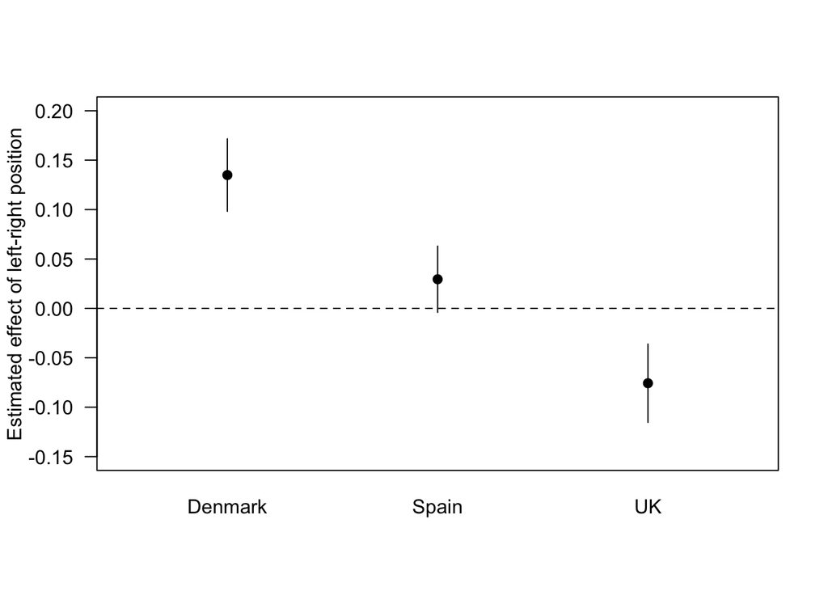

```r
# plot
#pdf(file="../output/effectsplot.pdf", height=6, width=4, family="URWTimes")
par(las = 1) # horizontal axis labels
nations <- c("Denmark", "Spain", "UK")
effects <- c(b_dk, b_es, b_uk)
# plot point estimates
plot(seq_along(nations), effects,  pch = 19, xlim = c(.5, 3.5), ylim = c(-.15, .2), xaxt = "n", xaxt = "n", ylab = "Estimated effect of left-right position", xlab = "")
# add 0 line
abline(h = 0, lty = 2)
# add nations labels
axis(1, seq_along(nations), nations, tick = FALSE)
# add confidence intervals
segments(1, conf95_denmark[1], 1, conf95_denmark[2])
segments(2, conf95_spain[1], 2, conf95_spain[2])
segments(3, conf95_uk[1], 3, conf95_uk[2])
```

```r
#dev.off()
```

#### 4. (Optional): check out how the “margins” package works! A good start might be

browseURL(“https://cran.r-project.org/web/packages/margins/vignettes/Introduction.html”) # Try to understand how this package is not only useful for visualizing conditional effects, but to calculate marginal effects in general and how this helps you communicate the implications of your models better!